# IMDB ratings: Differences between directors

2020-09-10

# IMDB ratings: Differences between directors

## Objective

In this section, we would like to reproduce this graph. We would be using `geom_errorbar()` and `geom_rect()`

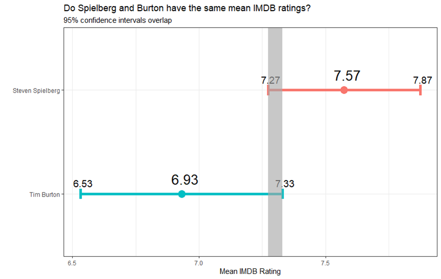

## Replicating the graph

First, we load the data and examine its structure.

```r
movies <- read_csv(here::here("data", "blog6_movies.csv"))
glimpse(movies)
```

```
## Rows: 2,961
## Columns: 11
## $ title               <chr> "Avatar", "Titanic", "Jurassic World", "The …
## $ genre               <chr> "Action", "Drama", "Action", "Action", "Acti…
## $ director            <chr> "James Cameron", "James Cameron", "Colin Tre…
## $ year                <dbl> 2009, 1997, 2015, 2012, 2008, 1999, 1977, 20…
## $ duration            <dbl> 178, 194, 124, 173, 152, 136, 125, 141, 164,…
## $ gross               <dbl> 7.61e+08, 6.59e+08, 6.52e+08, 6.23e+08, 5.33…
## $ budget              <dbl> 2.37e+08, 2.00e+08, 1.50e+08, 2.20e+08, 1.85…
## $ cast_facebook_likes <dbl> 4834, 45223, 8458, 87697, 57802, 37723, 1348…
## $ votes               <dbl> 886204, 793059, 418214, 995415, 1676169, 534…
## $ reviews             <dbl> 3777, 2843, 1934, 2425, 5312, 3917, 1752, 17…
## $ rating              <dbl> 7.9, 7.7, 7.0, 8.1, 9.0, 6.5, 8.7, 7.5, 8.5,…
```

Then we calculate the statistics and confidence interval needed for the plot.

```r
selected_directors <- movies %>%
                        select(director, rating) %>%
                        filter(director == "Tim Burton" | director == "Steven Spielberg") %>%
                        group_by(director) %>%
                        summarize(mean = mean(rating),
                                  sd = sd(rating),
                                  count = n(),
                                  se = sd/sqrt(count),
                                  t_critical = qt(0.975,count-1),
                                  lower_ci = mean - t_critical*se,
                                  upper_ci = mean + t_critical*se)

#selected_directors table
library(kableExtra)
kbl(selected_directors) %>%
  kable_styling(full_width = F) %>%
  kable_styling(bootstrap_options = c("striped", "hover", "condensed", "responsive"))
```

| director | mean | sd | count | se | t_critical | lower_ci | upper_ci |
| --- | --- | --- | --- | --- | --- | --- | --- |
| Steven Spielberg | 7.57 | 0.695 | 23 | 0.145 | 2.07 | 7.27 | 7.87 |
| Tim Burton | 6.93 | 0.749 | 16 | 0.187 | 2.13 | 6.53 | 7.33 |

```r
# we can do this easily in the pipe line but the format won't be so good-looking
#selected_directors %>%
  #select(director, mean, lower_ci, upper_ci) %>%
  #knitr::kable(digits = 2)
```

Finally we replicate the picture.

```r
# plot
idmb_plot <- ggplot(selected_directors, aes(x = mean, y = reorder(director, mean), color = director)) +
  geom_errorbar(aes(xmin = lower_ci, xmax = upper_ci), width = 0.1,size = 2) +
  labs(title = "Do Spielberg and Burton have the same IMDB ratings?",
       subtitle = "95% confidence intervals overlap",
       x = "Mean IMBD Rating",
       y = "") +
    geom_point(size = 4) +
   #add the mean
     geom_label(aes(y=reorder(director,mean),x=mean,
                   label = round(mean,2)),
                hjust=0.4, vjust=-0.3,
               color="black", fill=NA, label.size = NA, size=7.5)+
    #add the lower number
    geom_label(aes(y=reorder(director,mean),x=lower_ci,
                   label = round(lower_ci,2)),
                hjust=0.4, vjust=-0.3,
               color="black", fill=NA, label.size = NA, size=5)+
    #add the upper number
   geom_label(aes(y=reorder(director,mean),x=upper_ci,
                   label = round(upper_ci,2)),
                hjust=0.4, vjust=-0.3,
               color="black", fill=NA, label.size = NA, size=5)+
    geom_rect(aes(NULL,NULL,xmin=7.27,xmax=7.33,),
            ymin=0,ymax=3, colour="grey", size=0.5, alpha=0.2)+ #for ymax I just tried 1,2,3 and 3 seems a good fit
  theme_bw()+
  theme(legend.position = "none",aspect.ratio=0.6) + #this sets the ratio of height/width
  #guides(color=FALSE) #another way to remove legend of color is using guides()
  NULL
#idmb_plot

ggsave("imdb.jpg", plot = idmb_plot,path=here::here("static/img"),height =6, width=10 )
#knitr::include_graphics(here::here("static/img", "imdb.jpg"))
```

[output not shown]

## Hypothesis testing

In addition, we will run a hypothesis test. We would use both the `t.test` command and the `infer` package to simulate from a null distribution, where we assume zero difference between the two.

- The null hypothesis H0: there is no difference between the mean rating of movies directed by Tim Burton and those directed by Steven Spielberg.
- The alternative hypothesis Ha: there is difference between the mean rating of movies directed by Tim Burton and by Steven Spielberg.

```r
#prepare the dataset
movies_two <- movies %>%
              select(director, rating) %>%
              filter(director == "Steven Spielberg" | director == "Tim Burton")
t_movie<- t.test(rating~director,data=movies_two)
print(t_movie)
```

```
##
##  Welch Two Sample t-test
##
## data:  rating by director
## t = 3, df = 31, p-value = 0.01
## alternative hypothesis: true difference in means is not equal to 0
## 95 percent confidence interval:
##  0.16 1.13
## sample estimates:
## mean in group Steven Spielberg       mean in group Tim Burton
##                           7.57                           6.93
```

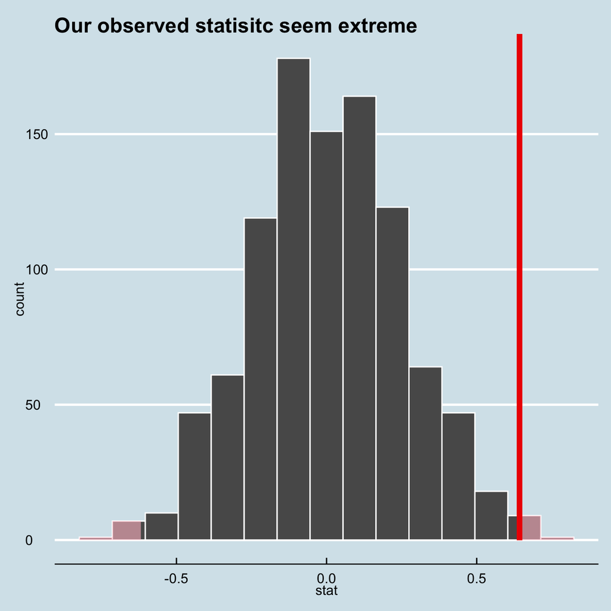

```r
obs_diff_imdb <- movies_two %>%
  specify(rating ~ director) %>%
  calculate(stat = "diff in means", order = c("Steven Spielberg","Tim Burton"))
#obs_diff_imdb
set.seed(1414) #we need to set seed
null_dist_imdb <- movies_two %>%
                  specify(rating ~ director) %>% #response is rating, exploratory is director
                  hypothesize(null = "independence") %>%
                  generate(reps = 1000, type = "permute") %>%
                  calculate(stat = "diff in means", order = c("Steven Spielberg", "Tim Burton"))
#null_dist_imdb
#ggplot(null_dist_imdb,aes(x=stat))+
  #geom_histogram(binwidth = 0.05)

#check where our sample’s observed statistic lie on this distribution
null_dist_imdb %>% visualize() +
  shade_p_value(obs_stat = obs_diff_imdb, direction = "two-sided")+
  labs(title="Our observed statisitc seem extreme")+
  theme_economist()
```

```r
#check the p-value
p_value_imdb <- null_dist_imdb %>%
  get_p_value(obs_stat = obs_diff_imdb, direction = "two_sided")
p_value_imdb
```

```
## # A tibble: 1 x 1
##   p_value
##     <dbl>
## 1   0.012
```

```r
#construct the CI
CI_imdb <- null_dist_imdb  %>%
# calculate the confidence interval around the point estimate
get_confidence_interval(point_estimate = obs_diff_imdb,
                          # at the 95% confidence level
                          level = .95,
                          # using the standard error
                          type = "se")
print(CI_imdb)
```

```
## # A tibble: 1 x 2
##   lower_ci upper_ci
##      <dbl>    <dbl>
## 1    0.151     1.13
```

```r
# we can find more information here https://infer.netlify.app/articles/infer.html
```

According to the results of Welch two sample t-test, the t-statistics is 3 (>2), the p-value is 0.01 (<0.05), and the 95% confidence interval is [0.16,1.13] (does not contain 0). And according to the results using `infer`, the p-value is 0.012 (<0.05), and the 95% confidence interval is [0.151,1.13] (does not contain 0).

Based on the consistent results above, we reject the null hypothesis and conclude there is difference between the mean rating of movies directed by Tim Burton and those directed by Steven Spielberg.